# R Notebook

# Data visualization

library(ggplot2) library(data.table)

# Data wrangling

library(mice) library(dummies) library(caret) library(caTools)

# Model building, Evaluation

library(rpart) library(rpart.plot) library(MLmetrics)

# Set working directory

setwd(“D:/R/MMT/datasete9dc3ed/dataset/”)

## Reading the file

mmt_trn_data <- read.csv(“train.csv”, na.strings = c(“”,“NA”))

```r
dim(mmt_trn_data)
```

```
[1] 552  17
```

```r
head(mmt_trn_data)
```

|  | id | A | B | C | D | E | F | G | H | I | J | K | L | M | N | O | P |
| --- | --- | --- | --- | --- | --- | --- | --- | --- | --- | --- | --- | --- | --- | --- | --- | --- | --- |
| 1 | 1 | b | 18.42 | 10.415 | y | p | aa | v | 0.125 | t | f | 0 | f | g | 120 | 375 | 1 |
| 2 | 2 | a | 21.75 | 11.750 | u | g | c | v | 0.250 | f | f | 0 | t | g | 180 | 0 | 1 |
| 3 | 3 | b | 30.17 | 1.085 | y | p | c | v | 0.040 | f | f | 0 | f | g | 170 | 179 | 1 |
| 4 | 4 | b | 22.67 | 2.540 | y | p | c | h | 2.585 | t | f | 0 | f | g | 0 | 0 | 0 |
| 5 | 5 | a | 36.00 | 1.000 | u | g | c | v | 2.000 | t | t | 11 | f | g | 0 | 456 | 0 |
| 6 | 6 | b | 31.25 | 1.125 | u | g | ff | ff | 0.000 | f | t | 1 | f | g | 96 | 19 | 1 |

```r
str(mmt_trn_data)
```

```
'data.frame':   552 obs. of  17 variables:
 $ id: int  1 2 3 4 5 6 7 8 9 10 ...
 $ A : Factor w/ 2 levels "a","b": 2 1 2 2 1 2 2 2 2 2 ...
 $ B : num  18.4 21.8 30.2 22.7 36 ...
 $ C : num  10.41 11.75 1.08 2.54 1 ...
 $ D : Factor w/ 3 levels "l","u","y": 3 2 3 3 2 2 2 2 2 2 ...
 $ E : Factor w/ 3 levels "g","gg","p": 3 1 3 3 1 1 1 1 1 1 ...
 $ F : Factor w/ 14 levels "aa","c","cc",..: 1 2 2 2 2 6 4 4 10 2 ...
 $ G : Factor w/ 9 levels "bb","dd","ff",..: 8 8 8 4 8 3 8 8 4 4 ...
 $ H : num  0.125 0.25 0.04 2.585 2 ...
 $ I : Factor w/ 2 levels "f","t": 2 1 1 2 2 1 1 1 2 1 ...
 $ J : Factor w/ 2 levels "f","t": 1 1 1 1 2 2 1 1 2 1 ...
 $ K : int  0 0 0 0 11 1 0 0 12 0 ...
 $ L : Factor w/ 2 levels "f","t": 1 2 1 1 1 1 1 2 2 2 ...
 $ M : Factor w/ 3 levels "g","p","s": 1 1 1 1 1 1 1 1 1 1 ...
 $ N : int  120 180 170 0 0 96 120 120 93 0 ...
 $ O : int  375 0 179 0 456 19 0 0 0 0 ...
 $ P : int  1 1 1 0 0 1 1 1 0 1 ...
```

```r
summary(mmt_trn_data)
```

```
       id           A             B               C             D          E             F             G
 Min.   :  1.0   a   :170   Min.   :13.75   Min.   : 0.000   l   :  2   g   :416   c      :115   v      :319
 1st Qu.:138.8   b   :374   1st Qu.:22.50   1st Qu.: 1.000   u   :416   gg  :  2   q      : 66   h      :113
 Median :276.5   NA's:  8   Median :28.17   Median : 2.750   y   :129   p   :129   w      : 50   bb     : 47
 Mean   :276.5              Mean   :31.36   Mean   : 4.780   NA's:  5   NA's:  5   i      : 47   ff     : 46
 3rd Qu.:414.2              3rd Qu.:37.66   3rd Qu.: 7.561                         ff     : 43   z      :  7
 Max.   :552.0              Max.   :80.25   Max.   :28.000                         (Other):224   (Other): 13
                            NA's   :9                                              NA's   :  7   NA's   :  7
       H          I       J             K          L       M             N                O                  P
 Min.   : 0.000   f:266   f:319   Min.   : 0.000   f:298   g:497   Min.   :   0.0   Min.   :     0.0   Min.   :0.0000
 1st Qu.: 0.165   t:286   t:233   1st Qu.: 0.000   t:254   p:  7   1st Qu.:  60.0   1st Qu.:     0.0   1st Qu.:0.0000
 Median : 1.000                   Median : 0.000           s: 48   Median : 152.0   Median :     3.5   Median :1.0000
 Mean   : 2.259                   Mean   : 2.319                   Mean   : 175.2   Mean   :  1087.6   Mean   :0.5525
 3rd Qu.: 2.750                   3rd Qu.: 3.000                   3rd Qu.: 268.0   3rd Qu.:   364.8   3rd Qu.:1.0000
 Max.   :28.500                   Max.   :40.000                   Max.   :1160.0   Max.   :100000.0   Max.   :1.0000
                                                                   NA's   :11
```

```r
md.pattern(mmt_trn_data)
```

```
    id C H I J K L M O P D E F G A B  N
524  1 1 1 1 1 1 1 1 1 1 1 1 1 1 1 1  1  0
  7  1 1 1 1 1 1 1 1 1 1 1 1 1 1 0 1  1  1
  8  1 1 1 1 1 1 1 1 1 1 1 1 1 1 1 0  1  1
  5  1 1 1 1 1 1 1 1 1 1 1 1 1 1 1 1  0  1
  1  1 1 1 1 1 1 1 1 1 1 1 1 0 0 1 1  1  2
  1  1 1 1 1 1 1 1 1 1 1 1 1 1 1 1 0  0  2
  1  1 1 1 1 1 1 1 1 1 1 1 1 0 0 0 1  1  3
  5  1 1 1 1 1 1 1 1 1 1 0 0 0 0 1 1  0  5
     0 0 0 0 0 0 0 0 0 0 5 5 7 7 8 9 11 52
```

# mmt_trn_data_na_rem <- na.omit(mmt_trn_data)

```r
#dim(mmt_trn_data_na_rem)
```

```r
#Data imputation
imputed_mmt_trn_data <- mice(mmt_trn_data, print = F, seed = 123)
imp_mmt_trn_data <- complete(imputed_mmt_trn_data)
md.pattern(imp_mmt_trn_data)
```

```
     id A B C D E F G H I J K L M N O P
[1,]  1 1 1 1 1 1 1 1 1 1 1 1 1 1 1 1 1 0
[2,]  0 0 0 0 0 0 0 0 0 0 0 0 0 0 0 0 0 0
```

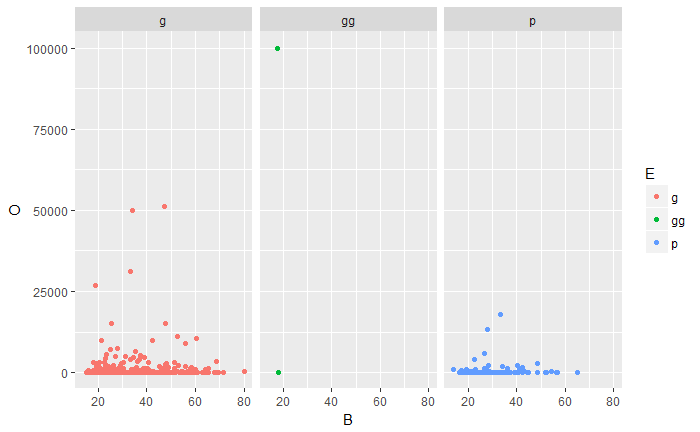

```r
#EXPLORATORY ANALYSIS
g <- ggplot(imp_mmt_trn_data, aes(x=B,y=O))
g + geom_point(aes(color = E)) + facet_wrap(~E)
```

# gg in E column seems outlier, should be removed

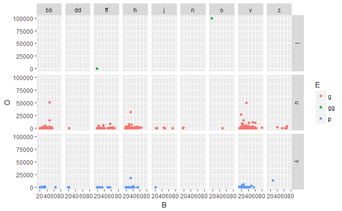

```r
g + geom_point(aes(color = E)) + facet_grid(D~G)
```

# n - 1and o 2 in G column seems outlier

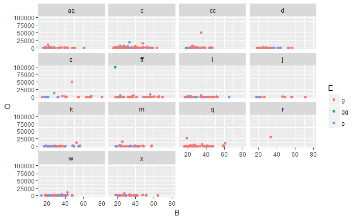

```r
g + geom_point(aes(color = E)) + facet_wrap(~F)
```

```r
##r in F column seems outlier
```

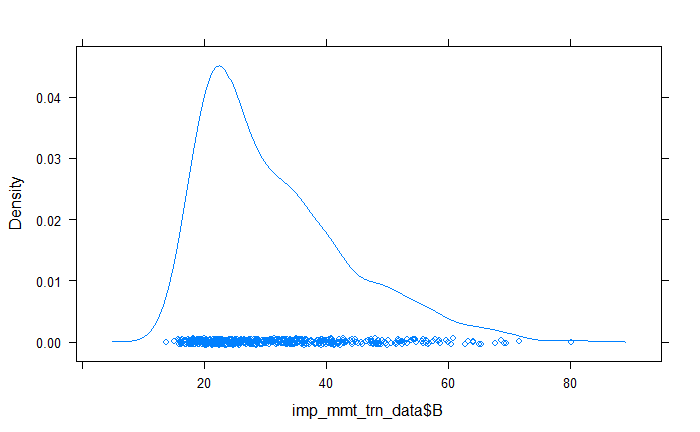

```r
densityplot(imp_mmt_trn_data$B)
```

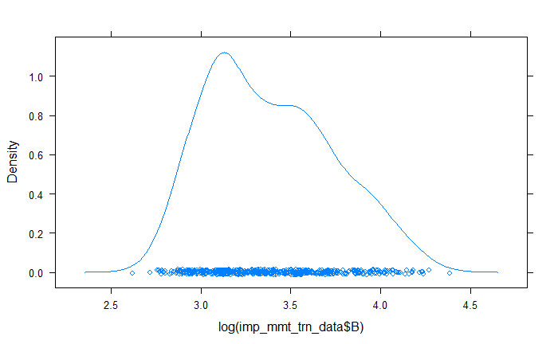

```r
densityplot(log(imp_mmt_trn_data$B))
```

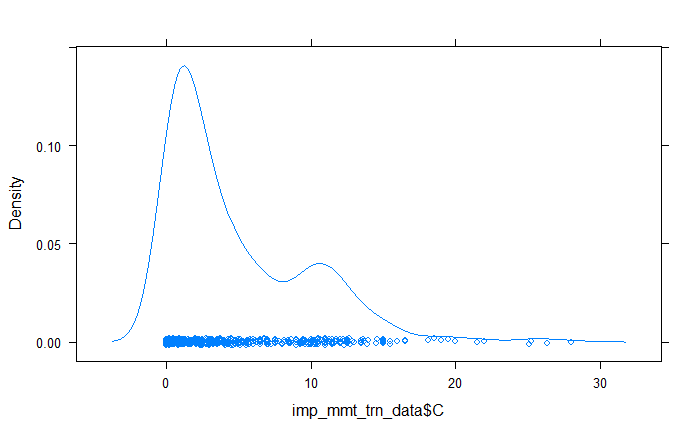

```r
#
densityplot(imp_mmt_trn_data$C)
```

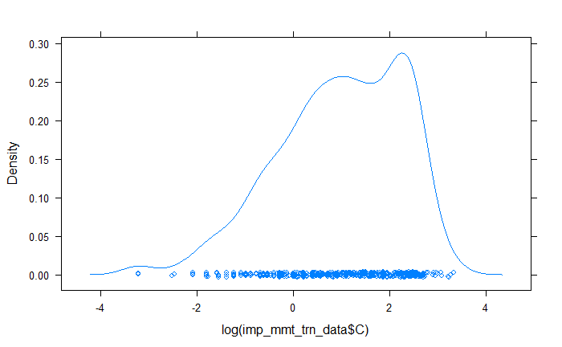

```r
densityplot(log(imp_mmt_trn_data$C))
```

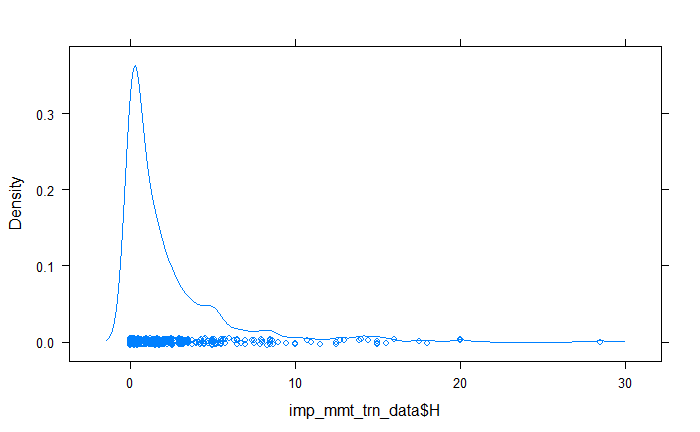

```r
densityplot(imp_mmt_trn_data$H)
```

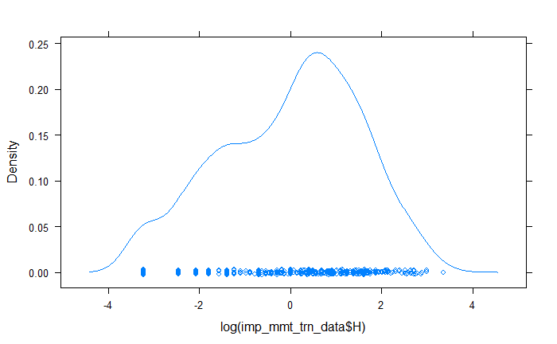

```r
densityplot(log(imp_mmt_trn_data$H))
```

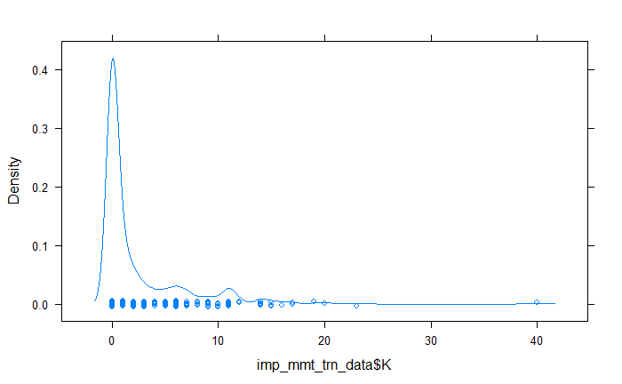

```r
densityplot(imp_mmt_trn_data$K)
```

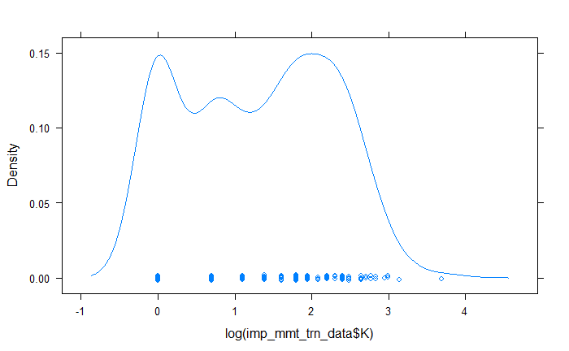

```r
densityplot(log(imp_mmt_trn_data$K))
```

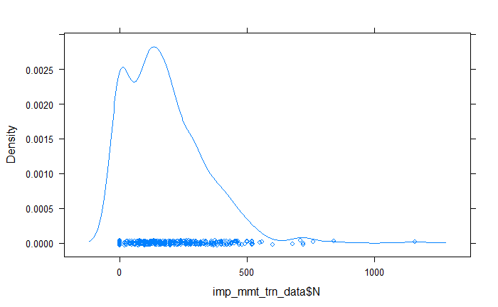

```r
densityplot(imp_mmt_trn_data$N)
```

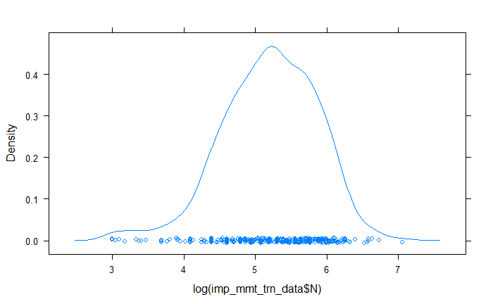

```r
densityplot(log(imp_mmt_trn_data$N))
```

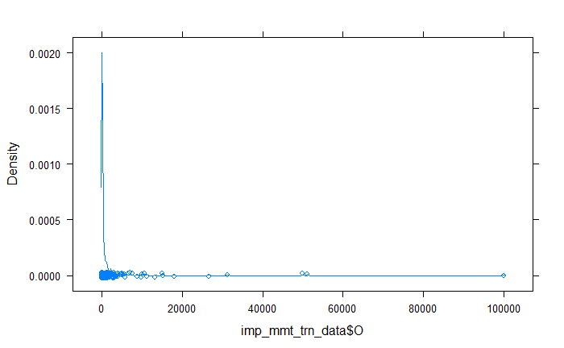

```r
densityplot(imp_mmt_trn_data$O)
```

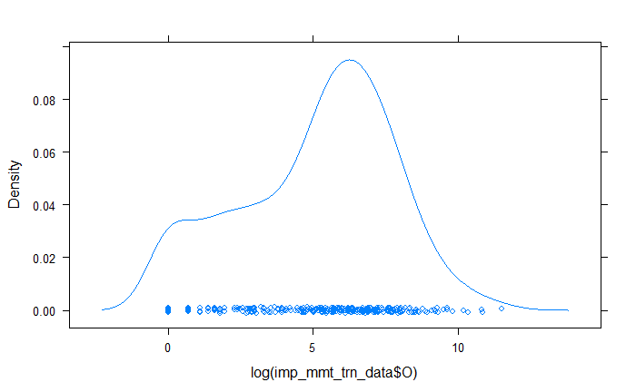

```r
densityplot(log(imp_mmt_trn_data$O))
```

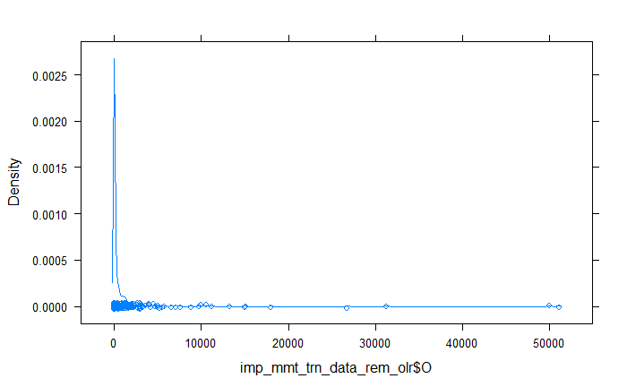

```r
#unselecting outlier id = 129
imp_mmt_trn_data_rem_olr <- imp_mmt_trn_data[imp_mmt_trn_data$id != 129,]
densityplot(imp_mmt_trn_data_rem_olr$O)
```

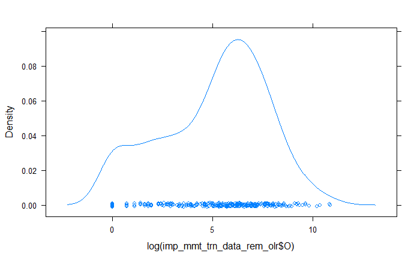

```r
densityplot(log(imp_mmt_trn_data_rem_olr$O))
```

```r
#removing outlier doesn't change the distribution so retaining id = 129
```

# Variable transformation of nominal variable

nom_feature <- c(“B”,“C”,“H”,“K”,“N”,“O”) temp_imp_mmt_trn_data <- imp_mmt_trn_data #replaing zeros of nominal column with smaller value which will be be closer to zero #after log transformation as zeros of log transformation would result in infinity temp_imp_mmt_trn_data[temp_imp_mmt_trn_data == 0] <- 1.001 temp_imp_mmt_trn_data[nom_feature] <- log(temp_imp_mmt_trn_data[nom_feature])

```r
head(temp_imp_mmt_trn_data)
```

|  | id | A | B | C | D | E | F | G | H | I | J | K | L | M | N | O | P |
| --- | --- | --- | --- | --- | --- | --- | --- | --- | --- | --- | --- | --- | --- | --- | --- | --- | --- |
| 1 | 1 | b | 2.913437 | 2.34324707 | y | p | aa | v | -2.0794415417 | t | f | 0.0009995003 | f | g | 4.7874917428 | 5.9269260260 | 1.000 |
| 2 | 2 | a | 3.079614 | 2.46385324 | u | g | c | v | -1.3862943611 | f | f | 0.0009995003 | t | g | 5.1929568509 | 0.0009995003 | 1.000 |
| 3 | 3 | b | 3.406848 | 0.08157999 | y | p | c | v | -3.2188758249 | f | f | 0.0009995003 | f | g | 5.1357984371 | 5.1873858058 | 1.000 |
| 4 | 4 | b | 3.121042 | 0.93216408 | y | p | c | h | 0.9497255080 | t | f | 0.0009995003 | f | g | 0.0009995003 | 0.0009995003 | 1.001 |
| 5 | 5 | a | 3.583519 | 0.00000000 | u | g | c | v | 0.6931471806 | t | t | 2.3978952728 | f | g | 0.0009995003 | 6.1224928095 | 1.001 |
| 6 | 6 | b | 3.442019 | 0.11778304 | u | g | ff | ff | 0.0009995003 | f | t | 0.0000000000 | f | g | 4.5643481915 | 2.9444389792 | 1.000 |

# Adding dummy variables for categorical data

imp_mmt_trn_data_dummy_var <- model.matrix(~ A + D + E + F + G + J + I + J + L + M + 0, data=imp_mmt_trn_data, contrasts.arg = lapply(data.frame(imp_mmt_trn_data[,sapply(data.frame(imp_mmt_trn_data),is.factor)]), contrasts, contrasts = FALSE)) merge_imp_mmt_trn_data <- cbind(temp_imp_mmt_trn_data,imp_mmt_trn_data_dummy_var)

final_merge_imp_mmt_trn_data <- subset(merge_imp_mmt_trn_data, select = -c(A, D , E , F , G , J , I , J , L , M))

```r
head(imp_mmt_trn_data_dummy_var)
```

```
  Aa Ab Dl Du Dy Eg Egg Ep Faa Fc Fcc Fd Fe Fff Fi Fj Fk Fm Fq Fr Fw Fx Gbb Gdd Gff Gh Gj Gn Go Gv Gz Jf Jt If It Lf Lt
1  0  1  0  0  1  0   0  1   1  0   0  0  0   0  0  0  0  0  0  0  0  0   0   0   0  0  0  0  0  1  0  1  0  0  1  1  0
2  1  0  0  1  0  1   0  0   0  1   0  0  0   0  0  0  0  0  0  0  0  0   0   0   0  0  0  0  0  1  0  1  0  1  0  0  1
3  0  1  0  0  1  0   0  1   0  1   0  0  0   0  0  0  0  0  0  0  0  0   0   0   0  0  0  0  0  1  0  1  0  1  0  1  0
4  0  1  0  0  1  0   0  1   0  1   0  0  0   0  0  0  0  0  0  0  0  0   0   0   0  1  0  0  0  0  0  1  0  0  1  1  0
5  1  0  0  1  0  1   0  0   0  1   0  0  0   0  0  0  0  0  0  0  0  0   0   0   0  0  0  0  0  1  0  0  1  0  1  1  0
6  0  1  0  1  0  1   0  0   0  0   0  0  0   1  0  0  0  0  0  0  0  0   0   0   1  0  0  0  0  0  0  0  1  1  0  1  0
  Mg Mp Ms
1  1  0  0
2  1  0  0
3  1  0  0
4  1  0  0
5  1  0  0
6  1  0  0
```

```r
head(merge_imp_mmt_trn_data)
```

|  | id | A | B | C | D | E | F | G | H | I | J | K | L | M | N | O | P | Aa | Ab | Dl | Du | Dy | Eg | Egg | Ep | Faa | Fc | Fcc | Fd | … |
| --- | --- | --- | --- | --- | --- | --- | --- | --- | --- | --- | --- | --- | --- | --- | --- | --- | --- | --- | --- | --- | --- | --- | --- | --- | --- | --- | --- | --- | --- | --- |
| 1 | 1 | b | 2.913437 | 2.34324707 | y | p | aa | v | -2.0794415417 | t | f | 0.0009995003 | f | g | 4.7874917428 | 5.9269260260 | 1.000 | 0 | 1 | 0 | 0 | 1 | 0 | 0 | 1 | 1 | 0 | 0 | 0 | … |
| 2 | 2 | a | 3.079614 | 2.46385324 | u | g | c | v | -1.3862943611 | f | f | 0.0009995003 | t | g | 5.1929568509 | 0.0009995003 | 1.000 | 1 | 0 | 0 | 1 | 0 | 1 | 0 | 0 | 0 | 1 | 0 | 0 | … |
| 3 | 3 | b | 3.406848 | 0.08157999 | y | p | c | v | -3.2188758249 | f | f | 0.0009995003 | f | g | 5.1357984371 | 5.1873858058 | 1.000 | 0 | 1 | 0 | 0 | 1 | 0 | 0 | 1 | 0 | 1 | 0 | 0 | … |
| 4 | 4 | b | 3.121042 | 0.93216408 | y | p | c | h | 0.9497255080 | t | f | 0.0009995003 | f | g | 0.0009995003 | 0.0009995003 | 1.001 | 0 | 1 | 0 | 0 | 1 | 0 | 0 | 1 | 0 | 1 | 0 | 0 | … |
| 5 | 5 | a | 3.583519 | 0.00000000 | u | g | c | v | 0.6931471806 | t | t | 2.3978952728 | f | g | 0.0009995003 | 6.1224928095 | 1.001 | 1 | 0 | 0 | 1 | 0 | 1 | 0 | 0 | 0 | 1 | 0 | 0 | … |
| 6 | 6 | b | 3.442019 | 0.11778304 | u | g | ff | ff | 0.0009995003 | f | t | 0.0000000000 | f | g | 4.5643481915 | 2.9444389792 | 1.000 | 0 | 1 | 0 | 1 | 0 | 1 | 0 | 0 | 0 | 0 | 0 | 0 | … |

```r
head(final_merge_imp_mmt_trn_data)
```

|  | id | B | C | H | K | N | O | P | Aa | Ab | Dl | Du | Dy | Eg | Egg | Ep | Faa | Fc | Fcc | Fd | Fe | Fff | Fi | Fj | Fk | Fm | Fq | Fr | Fw | … |
| --- | --- | --- | --- | --- | --- | --- | --- | --- | --- | --- | --- | --- | --- | --- | --- | --- | --- | --- | --- | --- | --- | --- | --- | --- | --- | --- | --- | --- | --- | --- |
| 1 | 1 | 2.913437 | 2.34324707 | -2.0794415417 | 0.0009995003 | 4.7874917428 | 5.9269260260 | 1.000 | 0 | 1 | 0 | 0 | 1 | 0 | 0 | 1 | 1 | 0 | 0 | 0 | 0 | 0 | 0 | 0 | 0 | 0 | 0 | 0 | 0 | … |
| 2 | 2 | 3.079614 | 2.46385324 | -1.3862943611 | 0.0009995003 | 5.1929568509 | 0.0009995003 | 1.000 | 1 | 0 | 0 | 1 | 0 | 1 | 0 | 0 | 0 | 1 | 0 | 0 | 0 | 0 | 0 | 0 | 0 | 0 | 0 | 0 | 0 | … |
| 3 | 3 | 3.406848 | 0.08157999 | -3.2188758249 | 0.0009995003 | 5.1357984371 | 5.1873858058 | 1.000 | 0 | 1 | 0 | 0 | 1 | 0 | 0 | 1 | 0 | 1 | 0 | 0 | 0 | 0 | 0 | 0 | 0 | 0 | 0 | 0 | 0 | … |
| 4 | 4 | 3.121042 | 0.93216408 | 0.9497255080 | 0.0009995003 | 0.0009995003 | 0.0009995003 | 1.001 | 0 | 1 | 0 | 0 | 1 | 0 | 0 | 1 | 0 | 1 | 0 | 0 | 0 | 0 | 0 | 0 | 0 | 0 | 0 | 0 | 0 | … |
| 5 | 5 | 3.583519 | 0.00000000 | 0.6931471806 | 2.3978952728 | 0.0009995003 | 6.1224928095 | 1.001 | 1 | 0 | 0 | 1 | 0 | 1 | 0 | 0 | 0 | 1 | 0 | 0 | 0 | 0 | 0 | 0 | 0 | 0 | 0 | 0 | 0 | … |
| 6 | 6 | 3.442019 | 0.11778304 | 0.0009995003 | 0.0000000000 | 4.5643481915 | 2.9444389792 | 1.000 | 0 | 1 | 0 | 1 | 0 | 1 | 0 | 0 | 0 | 0 | 0 | 0 | 0 | 1 | 0 | 0 | 0 | 0 | 0 | 0 | 0 | … |

# This data doesn’t have original categorical columns and nominal data has been transformed too